# Getting started: clustered IV with weak-instrument-robust inference (the queens data)

This vignette walks through the package’s workflow on a real, named dataset: Dube and Harish (2020) ask whether states ruled by queens fought more wars than states ruled by kings, instrumenting queenly rule with the gender composition of the previous ruler’s family. The design has everything this package is for: a binary endogenous regressor, multiple excluded instruments that are not strong, a moderate number of clusters (176 reign spells), and a covariate block that mixes dense controls with several fixed-effect dimensions.

The vignette is precomputed: the panel cannot be redistributed inside an R package, so the code was executed by the maintainer against a local copy and the outputs are stored. Every displayed result comes from the displayed code.

## Data

The analysis file is the main panel from the replication materials of Dube and Harish (2020, *Journal of Political Economy*): one row per polity-year, 3,586 rows and 778 columns. Set `data_path` to your local copy; the hashes let you confirm you hold the same file:

```r
data_path <- "queens_main_panel.dta"
```

```r
library(clusterIV)

d <- as.data.frame(haven::read_dta(data_path))
dim(d)
```

```
#> [1] 3586  778
```

```r
unname(tools::md5sum(data_path))
```

```
#> [1] "29d55f9aeac21a33d09c92bc279e829e"
```

The roles in the baseline specification (Dube and Harish, Table A.5, column 1):

- outcome `anypartBDICTC` — the polity participates in a war in that year;
- endogenous regressor `queen2` — a queen rules;
- excluded instruments `fb` (first-born child is male) and `femsib2` (previous ruler had a sister);
- clusters `inv1_clust_broadgreign_id` — 176 broad reign spells, the level at which assignment varies;
- dense controls `fbmg`, `mgsib2`, `inv1_any_NMBlc_hw`, `inv1_any_MBlc_hw`, `inv1_gunrel` (the family-composition and gun-related controls of the published specification);
- three fixed-effect dimensions: sibling count, decade, and polity.

It is an unweighted linear-probability IV model. The fixed-effect factors are built once:

```r
d$sibling_fe <- factor(d$totsib2)
d$decade_fe  <- factor(d$decade_indicator)
d$polity_fe  <- factor(d$kingdom_id)
c(G = length(unique(d$inv1_clust_broadgreign_id)),
  fe_levels = nlevels(d$sibling_fe) + nlevels(d$decade_fe) +
    nlevels(d$polity_fe))
```

```
#>         G fe_levels
#>       176        79
```

## One call: `iv_infer()`

`iv_infer()` is the recommended entry point. It returns the CJIVE point estimate, the cluster-jackknife Anderson–Rubin (CJAR) confidence set, and the cluster-jackknife score (CJS) test in one panel, sharing all the expensive preprocessing:

```r
panel <- iv_infer(
  anypartBDICTC ~ queen2 | fb + femsib2 |          # y ~ x | z | fe
    sibling_fe + decade_fe + polity_fe,
  data        = d,
  cluster     = ~ inv1_clust_broadgreign_id,       # 176 reign clusters
  controls    = ~ fbmg + mgsib2 + inv1_any_NMBlc_hw +
    inv1_any_MBlc_hw + inv1_gunrel,                # dense controls
  beta0       = 0,                                 # tested point null
  level       = 0.95,                              # set level
  calibration = "chisq",                           # CJAR critical value (default)
  variance    = "plain"                            # jackknife variance (default)
)
panel
```

```
#> Cluster IV inference panel (CJIVE + CJAR + CJS)
#> Call: iv_infer.formula(formula = anypartBDICTC ~ queen2 | fb + femsib2 |      sibling_fe + decade_fe + polity_fe, data = d, cluster = ~inv1_clust_broadgreign_id,      controls = ~fbmg + mgsib2 + inv1_any_NMBlc_hw + inv1_any_MBlc_hw +          inv1_gunrel, level = 0.95, beta0 = 0, calibration = "c…
#>
#>   CJIVE/Wald (H0: beta = 0): coefficient = 0.4134   cluster-robust SE = 0.1623   z = 2.546   p = 0.01089
#>     95% Wald interval = [0.09517, 0.7316]
#>   CJAR (H0: beta = 0): T = 3.737   one-sided p = 0.008761
#>     95% confidence set = [0.135, 0.8381]
#>   CJS (H0: beta = 0): LM = 5.778   p = 0.01623
#>     95% confidence set = [0.09477, 0.8839]
#>   F_CJ = 7.756   critical value = 1.996
#>   F_CJS^2 = 12.08   critical value = 3.841
#>   effective F (Montiel Olea-Pflueger) = 10.68   critical value (tau = 10%, alpha = 5%) = 19.53   K_eff = 1.899
#>   n = 3586   G = 176 clusters   k = 2 instruments
#>   max within-cluster leverage = 0.0774
#>   absorbed fixed effects: 3 dimension(s), 79 levels   raw nuisance count/n = 0.02287
```

How to read this panel:

- The **CJIVE row** is the point estimate with its cluster-robust Wald interval — report it for magnitude.
- The **CJAR set** stays valid when instruments are weak or many; when it disagrees with the Wald interval, trust the CJAR set.
- The **CJS line** tests the specific null `beta0`; its power profile complements CJAR’s.
- `F_eff` is the clustered effective first-stage F of Montiel Olea and Pflueger, with its simplified-TSLS critical value. Here it is *below* that critical value: the instruments are not strong, which is exactly the situation the CJAR/CJS sets are for. `F_CJ` plays the same role for the CJAR set itself — it is above its critical value precisely when the CJAR set is bounded.
- `maxlev` is the maximum within-cluster leverage; small values (here about 0.08) mean no single reign spell dominates the first stage.

The components are ordinary fitted objects:

```r
coef(panel$cjive)
```

```
#>    queen2
#> 0.4133645
```

```r
confint(panel$cjar)
```

```
#>         lower     upper
#> [1,] 0.135045 0.8381354
```

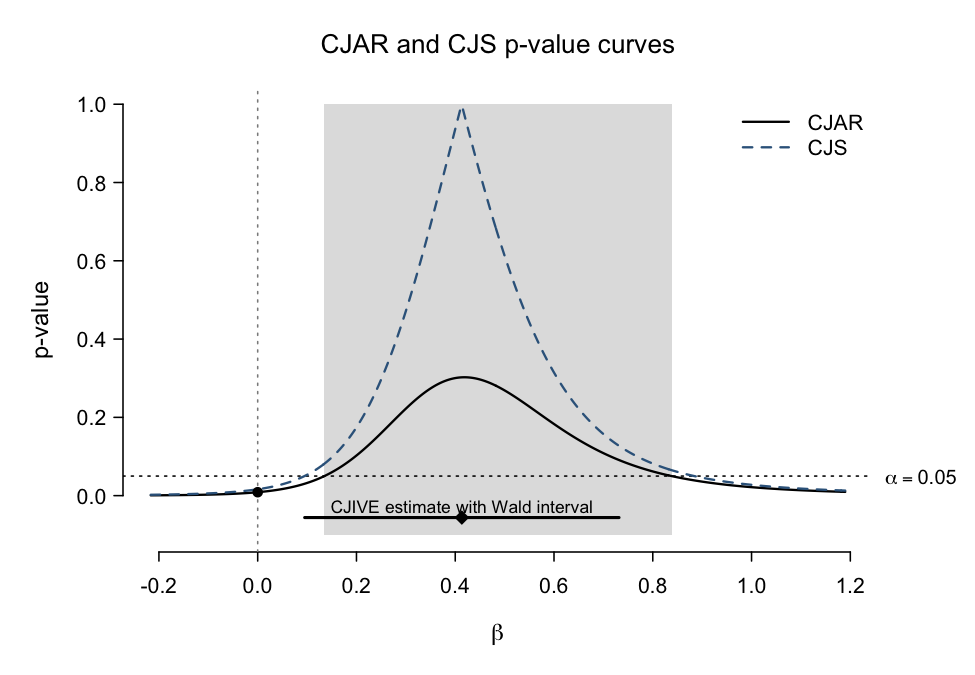

```r
plot(panel)
```

## Comparing estimators

`iv_compare()` reports OLS, 2SLS, the improved jackknife IV (IJIVE row, historically labelled JIVE), and CJIVE on the identical design. The published 2SLS coefficient for this specification is 0.388:

```r
W <- model.matrix(~ fbmg + mgsib2 + inv1_any_NMBlc_hw + inv1_any_MBlc_hw +
                    inv1_gunrel + sibling_fe + decade_fe + polity_fe,
                  data = d)[, -1L, drop = FALSE]
cmp <- iv_compare(d$anypartBDICTC, d$queen2,
                  z = data.matrix(d[, c("fb", "femsib2")]),
                  cluster  = d$inv1_clust_broadgreign_id,
                  controls = W)
print(cmp, digits = 3)
```

```
#>   estimator coefficient     se statistic  p.value conf.low conf.high
#> 1       OLS       0.130 0.0365      3.57 0.000362   0.0587     0.202
#> 2      2SLS       0.388 0.1449      2.68 0.007405   0.1040     0.672
#> 3      JIVE       0.389 0.1458      2.67 0.007556   0.1037     0.675
#> 4     CJIVE       0.413 0.1623      2.55 0.010891   0.0952     0.732
```

Two remarks. First, the OLS coefficient (0.13) is far below every IV estimate — the published paper’s point. Second, passing the fixed effects as dense `model.matrix` columns, as here, is numerically identical to absorbing them via `fixed_effects =`; the absorption route never forms the dummy matrix and is the one that scales.

## The published specification set

Table A.5 of Dube and Harish varies the instrument set (columns 1, 2, 4 and 5), and Ligtenberg (2025) adds a pooled specification using all five instruments. The loop below runs all five with the package, collecting the 2SLS anchor, the CJAR and CJS confidence sets, and the diagnostics:

```r
specs <- list(
  `A.5 col 1 (FBM, Sis)` = list(
    z = c("fb", "femsib2"),
    ctrl = c("fbmg", "mgsib2", "inv1_any_NMBlc_hw", "inv1_any_MBlc_hw",
             "inv1_gunrel")),
  `A.5 col 2 (+ Sis x No children)` = list(
    z = c("fb", "femsib2", "femsib2xnolc"),
    ctrl = c("fbmg", "mgsib2", "mgsib2xnolc", "inv1_any_NO_lc_hw",
             "inv1_gunrel")),
  `A.5 col 4 (+ Sis x FBM)` = list(
    z = c("fb", "femsib2", "femsib2xfb"),
    ctrl = c("fbmg", "mgsib2", "inv1_any_NMBlc_hw", "inv1_any_MBlc_hw",
             "inv1_gunrel")),
  `A.5 col 5 (+ FBM x Two children)` = list(
    z = c("fb", "fbxtwolc", "femsib2"),
    ctrl = c("fbmg", "fbmgxtwolc", "mgsib2", "inv1_two_lc_hw",
             "inv1_any_NMBlc_hw", "inv1_any_MBlc_hw", "inv1_gunrel")),
  `Pooled (all five instruments)` = list(
    z = c("fb", "femsib2", "femsib2xnolc", "femsib2xfb", "fbxtwolc"),
    ctrl = c("fbmg", "mgsib2", "mgsib2xnolc", "fbmgxtwolc",
             "inv1_any_NO_lc_hw", "inv1_two_lc_hw", "inv1_any_NMBlc_hw",
             "inv1_any_MBlc_hw", "inv1_gunrel"))
)

fmt_set <- function(cs) {
  if (nrow(cs) == 0L) return("(empty)")
  paste(apply(cs, 1L, function(z) sprintf("[%.3f, %.3f]", z[1L], z[2L])),
        collapse = " U ")
}

rows <- lapply(names(specs), function(nm) {
  s <- specs[[nm]]
  Ws <- model.matrix(
    stats::reformulate(c(s$ctrl, "sibling_fe", "decade_fe", "polity_fe")),
    data = d)[, -1L, drop = FALSE]
  z  <- data.matrix(d[, s$z])
  cmp <- iv_compare(d$anypartBDICTC, d$queen2, z,
                    cluster = d$inv1_clust_broadgreign_id, controls = Ws)
  ar <- cjar(d$anypartBDICTC, d$queen2, z,
             cluster = d$inv1_clust_broadgreign_id, controls = Ws)
  sc <- cjscore(d$anypartBDICTC, d$queen2, z,
                cluster = d$inv1_clust_broadgreign_id, controls = Ws)
  data.frame(spec = nm, k = ar$k,
             `2SLS` = cmp$coefficient[cmp$estimator == "2SLS"],
             CJIVE = cmp$coefficient[cmp$estimator == "CJIVE"],
             `CJAR 95% set` = fmt_set(ar$conf_set),
             `CJS 95% set` = fmt_set(sc$conf_set),
             F_CJ = round(ar$F_CJ, 2),
             check.names = FALSE)
})
tab <- do.call(rbind, rows)
print(tab, row.names = FALSE, digits = 3)
```

```
#>                              spec k  2SLS CJIVE   CJAR 95% set    CJS 95% set F_CJ
#>              A.5 col 1 (FBM, Sis) 2 0.388 0.413 [0.135, 0.838] [0.095, 0.884] 7.76
#>   A.5 col 2 (+ Sis x No children) 3 0.313 0.335 [0.241, 0.537] [0.087, 0.701] 8.33
#>           A.5 col 4 (+ Sis x FBM) 3 0.288 0.311 [0.133, 0.592] [0.008, 0.680] 7.29
#>  A.5 col 5 (+ FBM x Two children) 3 0.313 0.338 [0.086, 0.797] [0.092, 0.865] 5.66
#>     Pooled (all five instruments) 5 0.226 0.241 [0.037, 0.518] [0.032, 0.535] 7.08
```

The four A.5 rows reproduce the published 2SLS coefficients (0.388, 0.313, 0.288, 0.313) to three decimals; the CJIVE estimates and the CJAR/CJS confidence sets are the package’s own output, computed by exact polynomial inversion rather than a parameter grid.

## Exporting results

`tidy()` and `glance()` methods (registered through the optional `generics` package) return plain data frames, one row per inferential procedure, so results flow into `knitr::kable()`, `modelsummary`, or any LaTeX pipeline:

```r
library(generics)   # provides the tidy() / glance() generics
td <- tidy(panel)
td[, c("procedure", "estimate", "std.error", "statistic", "p.value",
       "conf.low", "conf.high", "shape")]
```

```
#>                          procedure  estimate std.error statistic     p.value   conf.low
#> 1                       CJIVE/Wald 0.4133645  0.162348  2.546163 0.010891440 0.09516822
#> 2 cluster jackknife Anderson-Rubin        NA        NA  3.737397 0.008761418 0.13504496
#> 3          cluster jackknife score        NA        NA  5.777926 0.016228678 0.09477295
#>   conf.high   shape
#> 1 0.7315609 bounded
#> 2 0.8381354 bounded
#> 3 0.8839396 bounded
```

A confidence set that is disjoint or unbounded cannot be flattened into two numbers; the full endpoint matrix always sits in the `conf.set` list-column, and `shape` says what kind of set each row carries. For a LaTeX table:

```r
knitr::kable(td[, c("procedure", "estimate", "std.error", "conf.low",
                    "conf.high")],
             format = "latex", digits = 3, booktabs = TRUE)
```

[output not shown]

## Caveats worth knowing here

- The baseline absorbs 79 fixed-effect levels and 5 dense controls in a sample of 3,586 — a raw nuisance share of about 2.3%, comfortably in the regime the theory covers. With *many* controls relative to the sample, the plug-in CJIVE standard error can over-reject (Kolesár, Min, Wang and Zhang 2026); see the FAQ in `?cjar`.
- The decade/polity/sibling effects here are generic controls, not cluster-specific ones; a small number of them partialled out ex ante is asymptotically negligible for the CJAR/CJS theory (Ligtenberg 2025, Section 5.3).
- This vignette applies the package’s independently validated formulas to the published specifications; it is a worked application, not a claimed replication of any table beyond the 2SLS/first-stage anchors quoted above.

## References

Dube, O. and Harish, S. P. (2020). Queens. *Journal of Political Economy*, 128(7), 2579–2652. The data and the published 2SLS specifications (Table A.5).

Ligtenberg, J. W. (2025). Inference in clustered IV models with many and weak instruments. arXiv:2306.08559v3. The CJAR and CJS tests and the pooled specification.

Frandsen, B., Leslie, E. and McIntyre, S. (2025). Cluster jackknife instrumental variables estimation. *Review of Economics and Statistics*. doi:10.1162/rest.a.263. The CJIVE estimator.

Montiel Olea, J. L. and Pflueger, C. (2013). A robust test for weak instruments. *Journal of Business & Economic Statistics*, 31(3), 358–369. The effective first-stage F reported as `F_eff`.